# Bellabeat Smart Device Usage Analysis

# 1 Statement of Business Task

Bellabeat is a high-tech company that manufactures health-focused innovative products for women. Their products include:

- Bellabeat app: provides users with health data related to their activity, sleep, stress, menstrual cycle, and mindfulness habits.
- Leaf: A tracker worn as a bracelet, necklace, or clip connects to the Bellabeat app to track activity, sleep and stress.
- Time: A watch that connects to the Bellabeat app to provide insights about the user’s wellness.
- Spring: A water bottle that tracks daily water intake using smart technology and connects to the Bellabeat app to track hydration levels.

The main business task is to analyze consumers’ usage of non-Bellabeat smart devices and apply those insights to recommend marketing strategies to Bellabeat.

# 2 Description of Data Sources

The data was stored in a public repository on the Kaggle platform. It contains personal fitness tracker data from thirty Fitbit users. I downloaded the Möbius data set organized in 18 separate .csv files, and after processing in SQL, I published a different data set on Kaggle.

## 2.2 Privacy

The dataset does not reveal any personal information of the survey participants. A unique ID represents all survey participants. Hence, data privacy is respected.

# 3 Data Preparation

Data cleaning and manipulation are performed in MySQL. There are a total of 18 datasets available. We observed that all data from ‘dailyIntensities_merged.csv’, ‘dailyCalories_merged.csv’ and ‘dailySteps_merged.csv’ are already in ‘dailyActivity_merged.csv’, hence ‘dailyActivity_merged.csv’ is used. As I am focusing on daily and hourly analysis, I will import the following datasets:

- dailyActivity_merged.csv
- heartrate_seconds_merged.csv
- hourlyCalories_merged.csv
- hourlyIntensities_merged.csv
- hourlySteps_merged.csv
- sleepDay_merge.csv
- weigthLog_Info_merged.csv

## 3.1 Dealing with DATETIME column

We observed that all files have a ‘Date’ column, but all fields under that column contain ‘AM’ or ‘PM’. SQL is unable to recognize the datatype as ‘DATETIME’. To resolve this issue, it is necessary to import ‘DATETIME’ as ‘STRING’. Then, we will create a new table using **CREATETABLE()** and use **STR_TO_DATE()** to change the data type from **STRING** to **DATETIME**.

```r
#Run the following code to connect to MySQL database
library(RMariaDB)
library(yaml)
# Load the configuration file
config <- yaml::read_yaml("C:/Users/Owner/OneDrive - Nanyang Technological University/Documents/config.yml")
password <- config$database$db_password
con <- dbConnect(MariaDB(),
                 user = "root",
                 password = password,
                 dbname = "fitbit",
                 host = "localhost",
                 port = 3306)
```

```sql
CREATE TABLE daily_activity (
  SELECT
      Id,
    STR_TO_DATE(ActivityDate, '%m/%d/%Y') AS Date,
    TotalSteps,
    TotalDistance,
    TrackerDistance,
    LoggedActivitiesDistance,
    VeryActiveDistance,
    ModeratelyActiveDistance,
    LightActiveDistance,
    SedentaryActiveDistance,
    VeryActiveMinutes,
    FairlyActiveMinutes,
    LightlyActiveMinutes,
    SedentaryMinutes,
    Calories
  FROM dailyactivity_merged
  ORDER BY Id, Date
);
```

```sql
CREATE TABLE heartrate AS (
  SELECT
    Id,
    STR_TO_DATE(Time, '%m/%d/%Y %h:%i:%S %p') AS SecondsTime,
    Value
  FROM heartrate_seconds_merged
  ORDER BY Id, SecondsTime
);
```

```sql
CREATE TABLE intensity_hour AS (
  SELECT
    Id,
    STR_TO_DATE(ActivityHour,'%m/%d/%Y %h:%i:%S %p') AS Date,
    TotalIntensity,
    AverageIntensity
  FROM hourlyintensities_merged
  ORDER BY Id, Date
);
```

```sql
CREATE TABLE steps_hour AS (
  SELECT
    Id,
    STR_TO_DATE(ActivityHour,'%m/%d/%Y %h:%i:%S %p') AS Date,
    StepTotal
  FROM hourlysteps_merged
  ORDER BY Id, Date
);
```

```sql
CREATE TABLE calories_hour AS (
    SELECT
        Id,
        STR_TO_DATE(ActivityHour, '%m/%d/%Y %h:%i:%S %p') AS Date,
        Calories
    FROM hourlycalories_merged
    ORDER BY Id, Date
);
```

```sql
CREATE TABLE weight AS (
  SELECT
    Id,
    DATE(STR_TO_DATE(Date,'%m/%d/%Y %h:%i:%S %p')) AS Date,
    WeightKg,
    BMI
  FROM weight_info
  ORDER BY Id, Date
);
```

```sql
CREATE TABLE sleep AS (
  SELECT
    Id,
    DATE(STR_TO_DATE(SleepDay,'%m/%d/%Y %h:%i:%S %p')) AS Date,
    TotalSleepRecords,
    TotalMinutesAsleep,
    TotalTimeInBed
  FROM sleepday_merge
  ORDER BY Id, Date
);
```

## 3.2 Check for duplicate rows

The following query is performed to check for any duplicate rows in each dataset:

```sql
SELECT
  (SELECT COUNT(1) FROM (SELECT DISTINCT * FROM sleep) AS derived_table_1) AS distinct_rows,
  (SELECT COUNT(1) FROM sleep) AS total_rows;
```

Table 3.1: 1 records

| distinct_rows | total_rows |
| --- | --- |
| 410 | 413 |

We observed that ‘sleepDay_merge.csv’ contains 3 duplicate rows. Using **DISTINCT** in the **SELECT** statement, we removed all duplicates and created a new table ‘sleep_daily’ which will be used for further analysis on daily sleep.

```sql
CREATE TABLE sleep_daily AS (
  SELECT DISTINCT *
  FROM sleep
);
```

## 3.3 Check for data consistency and comprehensiveness

### 3.3.1 daily_activity

The data seems to be consistent in daily_activity as there are no null values observed. There are a total of 33 participants by counting the number of DISTINCT Ids. The date records ranged from 04/12/2016 to 05/12/2016.

### 3.3.2 sleep_daily

The date range is consistent with daily_activity. There is also no data error, as all observations show that the total time in bed is more than the total minutes asleep. However, there were only 24 participants who recorded their sleep. Using **COUNT(DISTINCT SleepDate)** to check the number of records for each participant, we observed inconsistent sleep records among the 24 participants. The participant’s records range from 1 day to 31 days.

```sql
SELECT
  Id,
  COUNT(DISTINCT Date) AS sleep_record
FROM sleep_daily
GROUP BY Id
ORDER BY sleep_record DESC;
```

Table 3.2: Displaying records 1 - 10

| Id | sleep_record |
| --- | --- |
| 5553957443 | 31 |
| 6962181067 | 31 |
| 8378563200 | 31 |
| 2026352035 | 28 |
| 3977333714 | 28 |
| 4445114986 | 28 |
| 4702921684 | 27 |
| 4319703577 | 26 |
| 5577150313 | 26 |
| 1503960366 | 25 |

### 3.3.3 calories_hour, intensity_hour, steps_hour

The queries below are performed to check for null values in each dataset. Each result shows that there are no null values. All date ranges, and the number of participants in these datasets are also consistent with daily activity.

```sql
SELECT Id
FROM calories_hour
WHERE Calories IS NULL OR Calories<0;
```

Table 3.3: 0 records

| Id |
| --- |

```sql
SELECT Id
FROM intensity_hour
WHERE (TotalIntensity IS NULL OR TotalIntensity<0)
OR (AverageIntensity IS NULL OR AverageIntensity<0);
```

Table 3.4: 0 records

| Id |
| --- |

```sql
SELECT Id
FROM steps_hour
WHERE StepTotal IS NULL OR StepTotal<0;
```

Table 3.5: 0 records

| Id |
| --- |

### 3.3.4 weight

The date range is consistent with all other datasets, but there are only 8 participants who recorded their weight. Further analysis of the 8 participants will be done in the following section.

# 4 Data Manipulation

## 4.1 Hourly Analysis

To answer the question, “At what time are the average calories, steps and intensity the highest?” a **CTE** is created based on **LEFT JOIN** and columns **Id** and **Date**. We split the day into ‘morning’,’ afternoon’,’ night’ and ‘midnight’ based on a specific time range. The query below is performed to analyze each participant’s average intensity, calories and steps. The condition day= ‘night’ in the **WHERE** statement is changed to filter the results to ‘morning’, ‘afternoon’ and ‘midnight’.

```sql
CREATE TABLE p1 (
SELECT
    c.Id AS Id,
    c.Date AS Date,
    c.Calories,
    i.TotalIntensity,
    s.StepTotal,
    CASE WHEN TIME(c.Date) BETWEEN '00:00:00' AND '05:00:00' THEN 'midnight'
        WHEN TIME(c.Date) BETWEEN '06:00:00' AND '11:00:00'THEN 'morning'
        WHEN TIME(c.Date) BETWEEN '12:00:00' AND '17:00:00'THEN 'afternoon'
        ELSE 'night' END AS day
FROM calories_hour AS c
LEFT JOIN steps_hour AS s
ON c.Id=s.Id
    AND c.Date=s.Date
LEFT JOIN intensity_hour AS i
ON c.Id=i.Id
    AND c.Date=i.Date
);
```

```sql
SELECT
  Id,
  ROUND(SUM(AVG(Calories)) OVER (PARTITION BY Id),2) AS avg_calories,
  ROUND(SUM(AVG(TotalIntensity)) OVER (PARTITION BY Id),2) AS avg_intensity,
  ROUND(SUM(AVG(StepTotal)) OVER (PARTITION BY Id),2) AS avg_step,
  day
FROM p1
WHERE day='midnight'
GROUP BY Id,day;
```

```sql
SELECT
  Id,
  ROUND(SUM(AVG(Calories)) OVER (PARTITION BY Id),2) AS avg_calories,
  ROUND(SUM(AVG(TotalIntensity)) OVER (PARTITION BY Id),2) AS avg_intensity,
  ROUND(SUM(AVG(StepTotal)) OVER (PARTITION BY Id),2) AS avg_step,
  day
FROM p1
WHERE day='night'
GROUP BY Id,day;
```

```sql
SELECT
  Id,
  ROUND(SUM(AVG(Calories)) OVER (PARTITION BY Id),2) AS avg_calories,
  ROUND(SUM(AVG(TotalIntensity)) OVER (PARTITION BY Id),2) AS avg_intensity,
  ROUND(SUM(AVG(StepTotal)) OVER (PARTITION BY Id),2) AS avg_step,
  day
FROM p1
WHERE day='afternoon'
GROUP BY Id,day;
```

```sql
SELECT
  Id,
  ROUND(SUM(AVG(Calories)) OVER (PARTITION BY Id),2) AS avg_calories,
  ROUND(SUM(AVG(TotalIntensity)) OVER (PARTITION BY Id),2) AS avg_intensity,
  ROUND(SUM(AVG(StepTotal)) OVER (PARTITION BY Id),2) AS avg_step,
  day
FROM p1
WHERE day='morning'
GROUP BY Id,day;
```

## 4.2 Weight Analysis

To compare the weight, BMI, total steps and distance taken among the 8 participants, we perform **LEFT JOIN** based on column Id. Since the weight and BMI in the ‘weight’ dataset are recorded daily, we create a **CTE** ‘w’ to calculate each participant’s average weight and BMI. A second **CTE** ‘act’ is created to analyse the total steps and distance among these 8 participants. Then, the weight range is split into “obesity”, “overweight”, “healthy” and “underweight”. According to NHS,

- BMI below 18.5: underweight range
- BMI between 18.5 and 24.9: healthy weight range
- BMI between 25 and 29.9: overweight range
- BMI 30 or over: obese range

```sql
WITH w AS(
SELECT
    Id,
    ROUND(SUM(AVG(WeightKg)) OVER (PARTITION BY Id),2) AS avg_weight,
    ROUND(SUM(AVG(BMI)) OVER (PARTITION BY Id),2) AS avg_bmi
FROM weight
GROUP BY Id
ORDER BY avg_weight DESC),

act AS(
    SELECT
        Id,
        ROUND(SUM(AVG(TotalSteps)) OVER (PARTITION BY Id),2) AS step,
        ROUND(SUM(AVG(TotalDistance)) OVER (PARTITION BY Id),2) AS dist
    FROM daily_activity
    GROUP BY Id)

SELECT
    w.Id,
    w.avg_weight,
    w.avg_bmi,
    act.step,
    act.dist,
    CASE WHEN w.avg_bmi>=30 THEN 'obesity'
        WHEN w.avg_bmi BETWEEN 25 AND 29.99 THEN 'overweight'
        WHEN w.avg_bmi BETWEEN 18.5 AND 24.99 THEN 'healthy'
        ELSE 'underweight' END AS weight_range
FROM w
LEFT JOIN act
ON w.Id=act.Id
ORDER BY act.step DESC;
```

## 4.3 Daily Activity Analysis

Based on the average number of steps, the participants fall under these categories: “sedentary_active”, “lightly_active”, “moderately_active” and “very_active”. The classification divides the whole sample into 4 groups:

- Sedentary active: Less than 5000 steps
- Lightly active: 5000 to 7499 steps
- Moderately active: 7500 to 9999 steps
- Very active: Above 10000 steps

**DAYOFWEEK(Date)** is used to analyze the active level of participants each day.

```sql
SELECT
  Id,
  AVG(Calories) AS avg_calories,
  AVG(TotalSteps) AS avg_step,
  AVG(TotalDistance) AS avg_dist,
  DAYOFWEEK(Date) AS dayofweek,
  CASE WHEN AVG(TotalSteps)<5000 THEN 'sedentary_active'
      WHEN AVG(TotalSteps) BETWEEN 5000 AND 7499 THEN 'lightly_active'
      WHEN AVG(TotalSteps) BETWEEN 7500 AND 9999 THEN 'moderately_active'
      ELSE 'very_active' END AS active_level
FROM daily_activity
GROUP BY Id, dayofweek
ORDER BY Id,dayofweek;
```

## 4.4 Sleep Analysis

```sql
WITH avgsleep AS(
SELECT
  Id,
  COUNT(DISTINCT Date) AS total_records,
  ROUND(SUM(TotalMinutesAsleep/60)/COUNT(DISTINCT Date),2) AS avghours_sleep,
  ROUND(SUM(TotalTimeInBed/60)/COUNT(DISTINCT Date),2) AS avghours_bed
FROM sleep_daily
GROUP BY Id
ORDER BY total_records DESC)

SELECT
  avgsleep.Id,
  avgsleep.total_records,
  avgsleep.avghours_sleep,
  avgsleep.avghours_bed,
  CASE WHEN avgsleep.avghours_sleep<7 THEN 'insufficient'
    WHEN avgsleep.avghours_sleep>=9 THEN 'oversufficient'
    ELSE 'sufficient' END AS sleep_sufficiency
FROM avgsleep
ORDER BY avgsleep.total_records DESC;
```

In order to examine the sleep patterns of users on weekends vs weekdays, we add a condition using **CASE WHEN()** to determine whether the date falls under weekday or weekend. The average sleep duration is compared to analyze whether there is a difference in participants’ sleep habits.

```sql
SELECT
  CASE WHEN DAYOFWEEK(Date) IN (2,3,4,5,6) THEN "weekday"
    ELSE "weekend" END AS dayofweek,
  AVG(ROUND(TotalMinutesAsleep/60,2)) AS avghours_sleep
FROM sleep_daily
GROUP BY dayofweek;
```

# 5 Data Visualization

We perform data visualization in R. We import each SQL results in Chapter 4 into R studio. In R Studio, we need to import the following libraries:

```r
library(dplyr)
```

```r
library(ggplot2)
library(tidyverse)
library(lubridate)
library(scales)
library(gridExtra)
```

## 5.1 Graphical analysis of hourly activity

To answer the question “At what time are the average calories, steps and intensity the highest?”, we group the time of day into “morning”, “afternoon”, “night”, and “midnight”. The 4 data sets are bound together using rbind(), and the time of day is then converted to factor levels.

The box plots of average calories, steps and intensity are illustrated below. The highest average calories, steps and intensity occur in the afternoon, while the lowest number is observed at midnight. As participants are asleep at midnight, this can explain their low activity level.

```r
#bind morning,afternoon,night and midnight data sets together
df<-rbind(midnight_analysis,morning_analysis)
df1<-rbind(df,afternoon_analysis)
df2<-rbind(df1,night_analysis)
df2$day<-factor(df2$day,levels=c("morning","afternoon","night","midnight"))
str(df2)
```

```
## 'data.frame':    132 obs. of  5 variables:
##  $ Id           :integer64 1503960366 1624580081 1644430081 1844505072 1927972279 2022484408 2026352035 2320127002 ...
##  $ avg_calories : num  51.5 53 88.7 57.9 86.3 ...
##  $ avg_intensity: num  2.35 2.04 1.8 0.85 0.1 0 0.47 3.38 0.2 1.92 ...
##  $ avg_step     : num  39.88 34.81 28.51 20.75 1.03 ...
##  $ day          : Factor w/ 4 levels "morning","afternoon",..: 4 4 4 4 4 4 4 4 4 4 ...
```

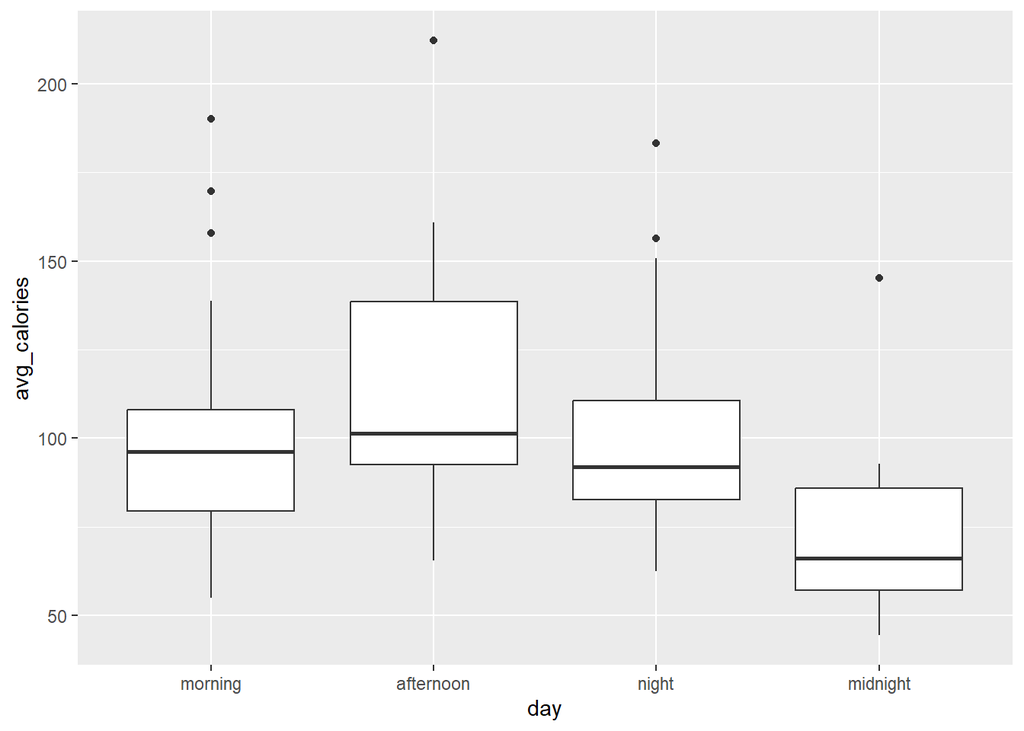

Figure 5.1: Box plot of average calories

```r
#boxplot the time analysis for average calories,intensity and step per day
df2 %>% ggplot(aes(x=day,y=avg_calories))+geom_boxplot()
```

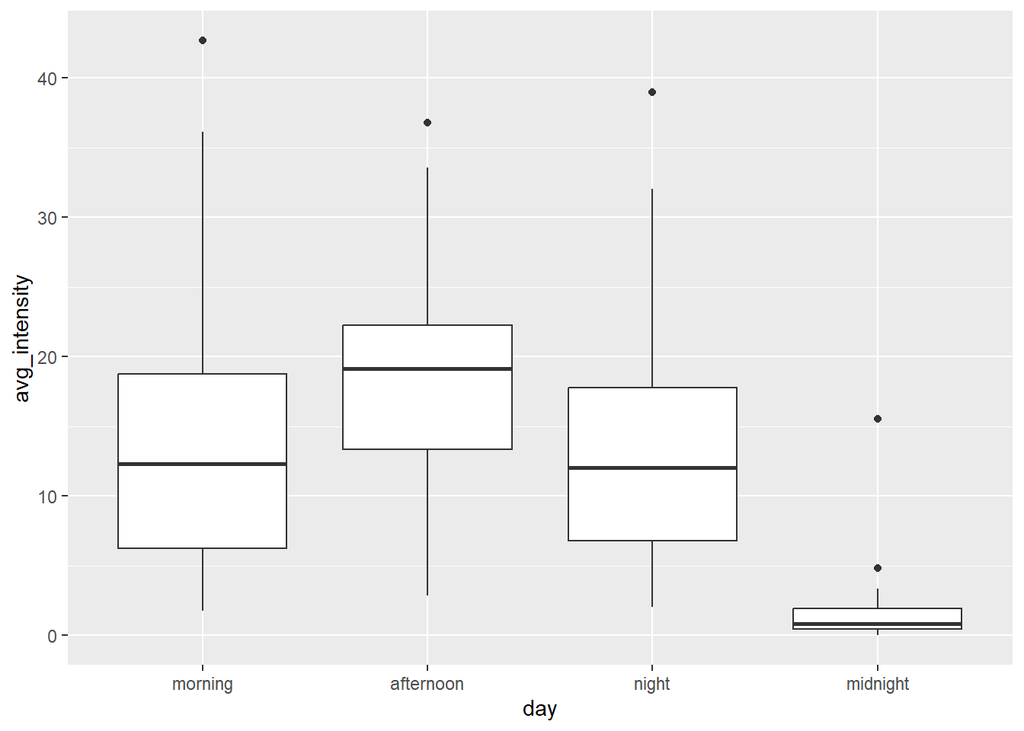

Figure 5.2: Box plot of average intensities

```r
df2 %>% ggplot(aes(x=day,y=avg_intensity))+geom_boxplot()
```

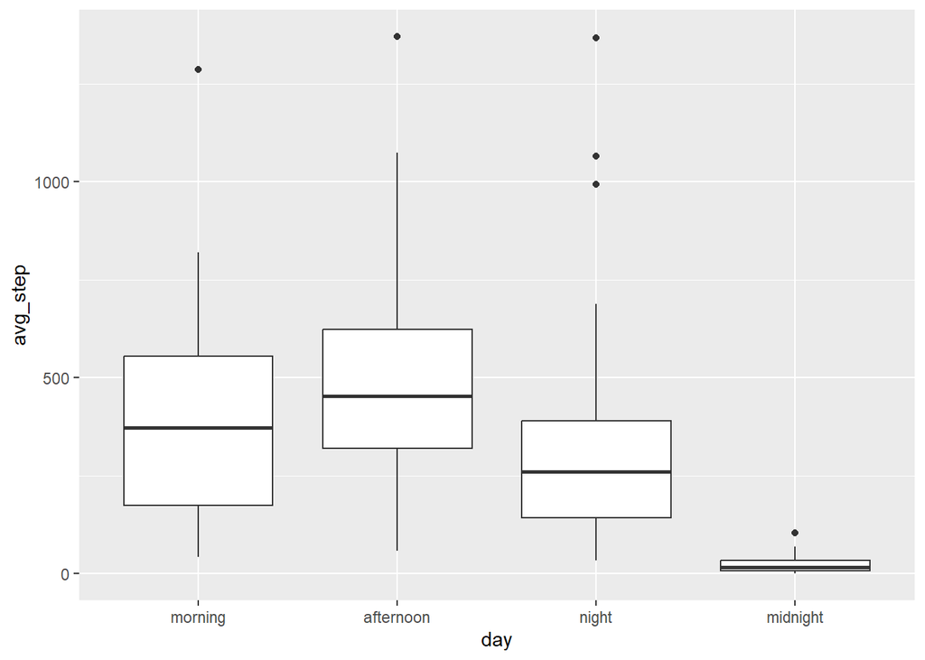

Figure 5.3: Box plot of average steps

```r
df2 %>% ggplot(aes(x=day,y=avg_step))+geom_boxplot()
```

## 5.2 Graphical analysis of weight

The following code finds the distribution of weight range. The distribution of weight is represented by a pie chart below.

```r
#Convert weight_range to factor levels
weight_analysis$weight_range<-factor(weight_analysis$weight_range,levels=c("healthy","overweight","obesity"))
str(weight_analysis)
```

```
## 'data.frame':    8 obs. of  6 variables:
##  $ Id          :integer64 8877689391 1503960366 6962181067 5577150313 4558609924 2873212765 4319703577 1927972279
##  $ avg_weight  : num  85.2 52.6 61.5 90.7 69.6 ...
##  $ avg_bmi     : num  25.5 22.6 24 28 27.2 ...
##  $ step        : num  16040 12117 9795 8304 7685 ...
##  $ dist        : num  13.16 7.87 6.68 6.23 4.94 ...
##  $ weight_range: Factor w/ 3 levels "healthy","overweight",..: 2 1 1 2 2 1 2 3
```

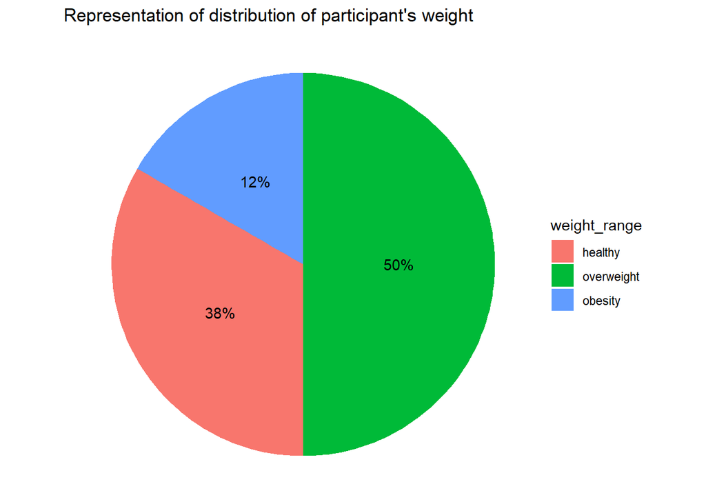

```r
#Find the distribution of weight range
summary_weight<- weight_analysis %>%
  group_by(weight_range=weight_analysis$weight_range) %>%
  count() %>%
  ungroup() %>%
  mutate(percentage= percent(n/sum(n)))

#Visualize the distribution in pie chart
ggplot(summary_weight,aes(x="",y=percentage,fill=weight_range))+
  geom_col()+
  geom_text(aes(label=percentage),
            position=position_stack(vjust=0.5),)+
  coord_polar(theta="y")+
  theme_void()+
  labs(title="Representation of distribution of participant's weight")
```

- **Active level performance**

We will use a bar chart to visualize the average steps achieved by the 8 participants.

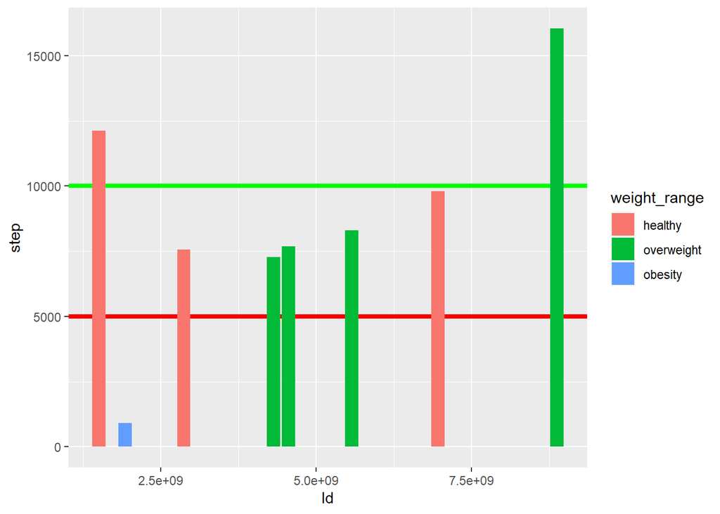

Figure 5.4: Average steps among 8 participants

```r
weight_analysis$Id<-as.numeric(weight_analysis$Id)
#Analysis on the participants active performance
ggplot(weight_analysis,aes(fill=weight_range,y=step,x=Id))+
  geom_hline(yintercept = 5000, linewidth = 1.5, color = "red", group = 1)+
  geom_hline(yintercept = 10000, linewidth = 1.5, color = "green", group = 1)+
  geom_bar(position="dodge",stat="identity")
```

Figure 5.4 shows that all overweight and healthy participants hit the minimum 5000 steps goal. The obese participant achieves the lowest number of steps. Among the participants, only one healthy and one overweight participant hit an average of 10,000 steps daily. Thus, measures are needed to encourage participants to adopt a more active lifestyle.

## 5.3 Graphical analysis of sleep

To analyze participants’ sleep patterns, we focus on categorizing users based on their average sleep duration each day.

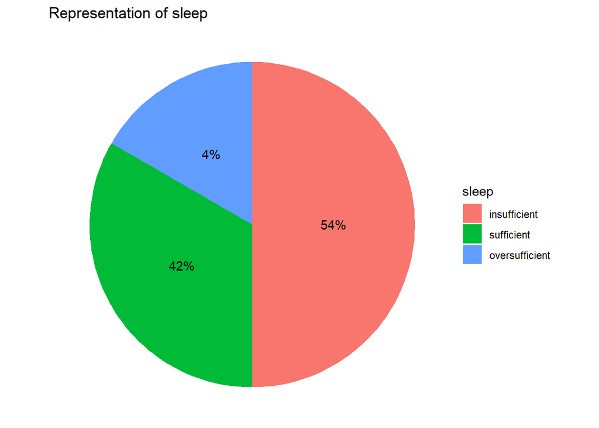

```r
#Convert sleep_sufficiency into factor levels
sleep_analysis$sleep_sufficiency<-factor(sleep_analysis$sleep_sufficiency,levels=c("insufficient","sufficient","oversufficient"))

#group and count participants according to their sleep sufficiency
summary_sleep<- sleep_analysis %>%
  group_by(sleep=sleep_analysis$sleep_sufficiency) %>%
  count() %>%
  ungroup() %>%
  mutate(percentage= percent(n/sum(n)))

#Visualize in pie chart
ggplot(summary_sleep,aes(x="",y=percentage,fill=sleep))+
  geom_col()+
  geom_text(aes(label=percentage),
            position=position_stack(vjust=0.5),)+
  coord_polar(theta="y")+
  theme_void()+
  labs(title="Representation of sleep")
```

Among 24 participants, 42% of them have sufficient sleep duration. However, 54% of them do not have an adequate amount of sleep. Thus, this highlights the prevalence of insufficient sleep among the analyzed participants.

- **Sleep performance throughout the week**

To visualize participants’ sleep duration on weekdays and weekends, we will use a bar chart for comparison. Based on the bar chart, there is a slight difference in sleep duration between weekdays and weekends. It suggests that participants can catch up on sleep or follow a different sleep routine during weekends, resulting in slightly longer sleep duration.

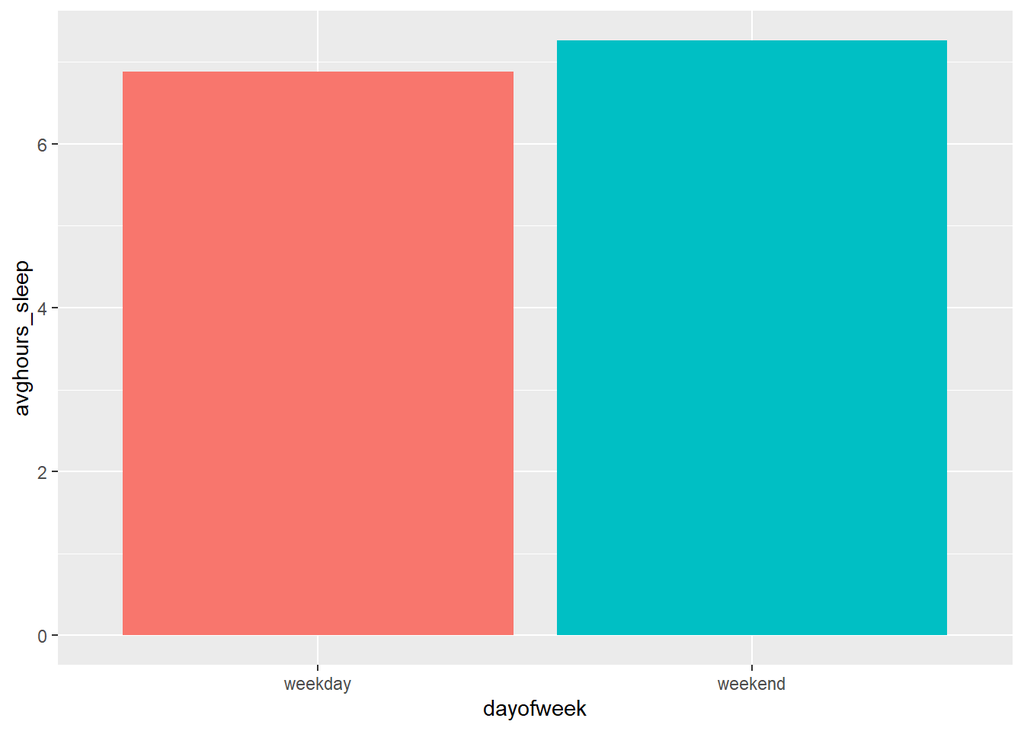

```r
#total sleep duration on weekdays and weekends
ggplot(sleepday_analysis, aes(x =dayofweek,y=avghours_sleep,fill=dayofweek))+
  geom_bar(stat="identity")+
  theme(legend.position="none")
```

- **Relationship between time in bed and time asleep**

We create a scatter plot to test our hypothesis on whether there is a correlation between time in bed and time asleep.

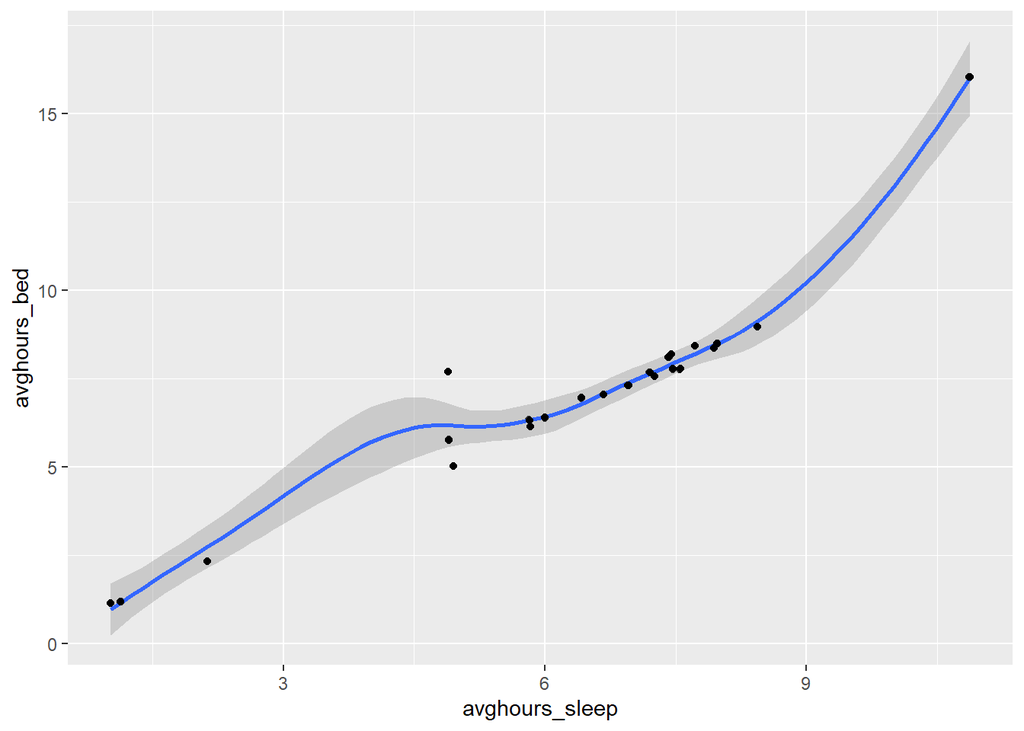

Figure 5.5: Scatter Plot between avghours_sleep and avghours_bed

```r
ggplot(sleep_analysis,aes(x=avghours_sleep,y=avghours_bed))+geom_point()+geom_smooth()+geom_jitter()
```

The scatter plot (See Figure 5.5) shows that there is a strong positive correlation between the two variables. As participants spend more time in bed, their sleep duration increases.

- **Relationship between sleep records and sleep duration**

We also test our hypothesis on the relationship between the total number of sleep records and the average sleep duration. From Figure 5.6, one surprising observation is that as participants record their sleep records more frequently, they tend to sleep longer. It suggests that those who use the device more regularly have better sleep quality.

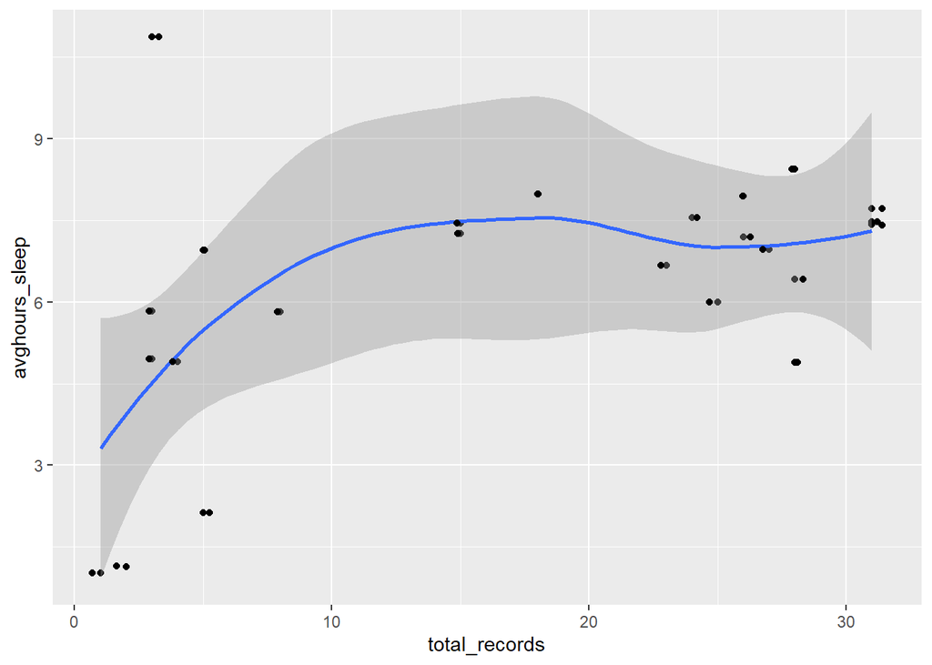

Figure 5.6: Scatter Plot between total_records and avghours_sleep

```r
sleep_analysis$total_records<-as.numeric(sleep_analysis$total_records)
ggplot(sleep_analysis,aes(x=total_records,y=avghours_sleep))+geom_point()+geom_smooth()+geom_jitter()
```

## 5.4 Graphical Analysis of daily activity

The distribution of active_level among the population is represented by a pie chart.

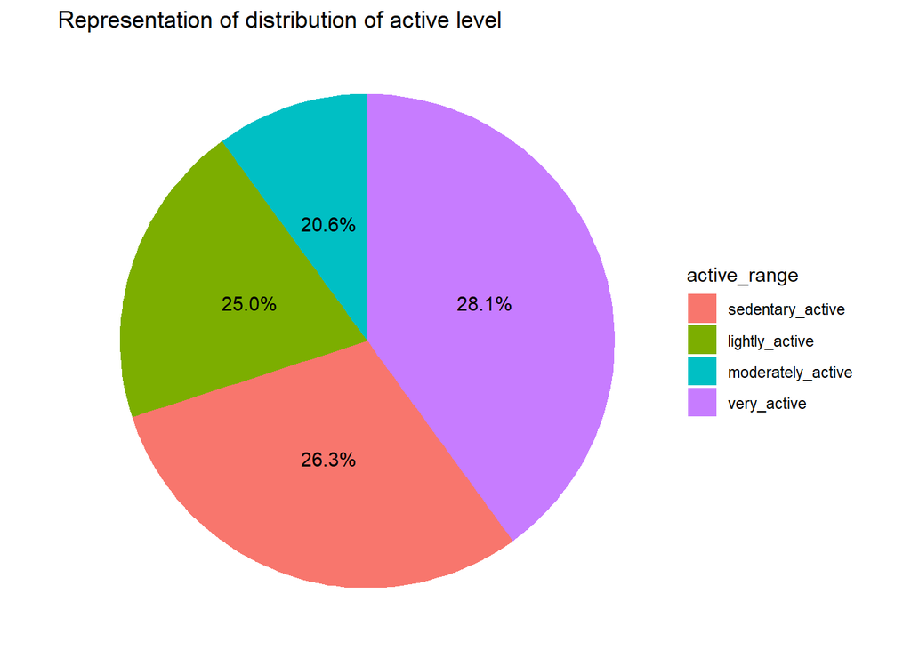

```r
#Convert active level range to factor levels
active_analysis$active_level<-factor(active_analysis$active_level,levels=c("sedentary_active","lightly_active","moderately_active","very_active"))
#Convert day of week to factor levels
active_analysis$dayofweek<-factor(active_analysis$dayofweek,levels=c("1","2","3","4","5","6","7"))

#Group and count the number of participants based on their active level
summary_active<- active_analysis %>%
  group_by(active_range=active_analysis$active_level) %>%
  count() %>%
  ungroup() %>%
  mutate(percentage= percent(n/sum(n)))

#Visualize in pie chart
ggplot(summary_active,aes(x="",y=percentage,fill=active_range))+
  geom_col()+
  geom_text(aes(label=percentage),
            position=position_stack(vjust=0.5),)+
  coord_polar(theta="y")+
  theme_void()+
  labs(title="Representation of distribution of active level")
```

The result shows that the biggest group are those who take more than 10000 steps and represent the very_active group. The sedentary represents the second biggest group, with 26.3% of the population, followed by the lightly_active group, which constitutes 25%. The moderately_active individuals represent the smallest group with a little more than 20% over the total. The large percentage of the population who lived a sedentary lifestyle is alarming as this can have significant long-term impacts on one physical and mental well-being. Thus, more measures are needed to encourage users to achieve the recommended total daily steps.

- **Daily activity performance throughout the week**

We analyze the average steps taken throughout the week in a grouped bar chart.

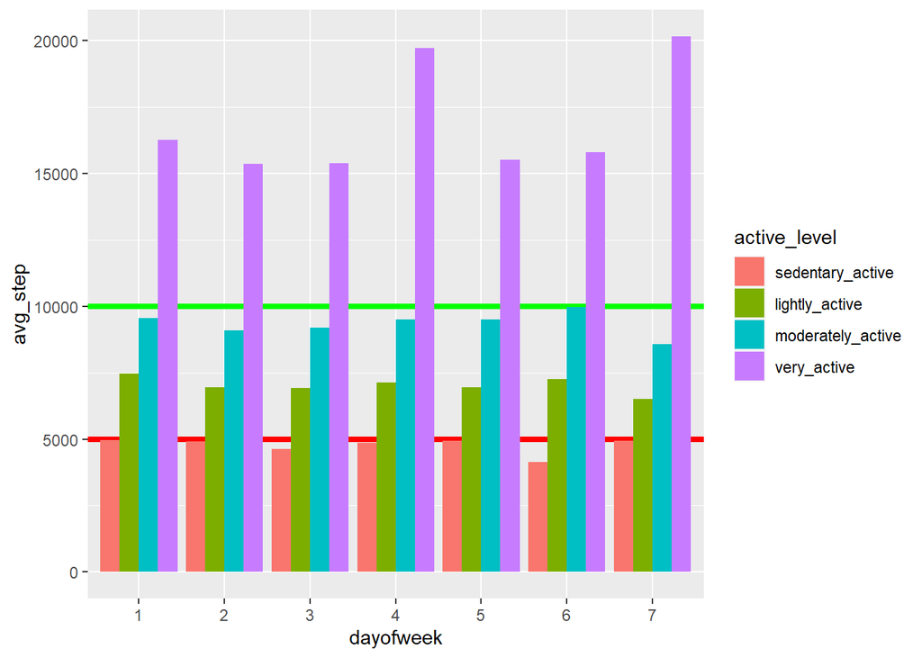

Figure 5.7: average steps throughout the week

```r
#Visualize average steps throughout the week
ggplot(active_analysis,aes(fill=active_level,y=avg_step,x=dayofweek))+
  geom_hline(yintercept = 5000, linewidth = 1.5, color = "red", group = 1)+
  geom_hline(yintercept = 10000, linewidth = 1.5, color = "green", group = 1)+
  geom_bar(position="dodge",stat="identity")
```

Based on the bar chart (See Figure 5.7), for very active participants, they perform best on Saturday. Moderately active and lightly active participants are relatively constant throughout the week, with better performance on Friday. Sedentary active participants do not hit the minimum goal of 5000 steps on any of the weekdays and tend to record fewer steps on weekdays.

- **Relationships between calories, distance and steps**

Both the numerical measure and visualization of the relationships between any pair of variables (See Figure 5.8) show that average_step and avg_distance are highly and linearly related, followed by the relationships between average_calories and average_distance, average calories and average_steps.

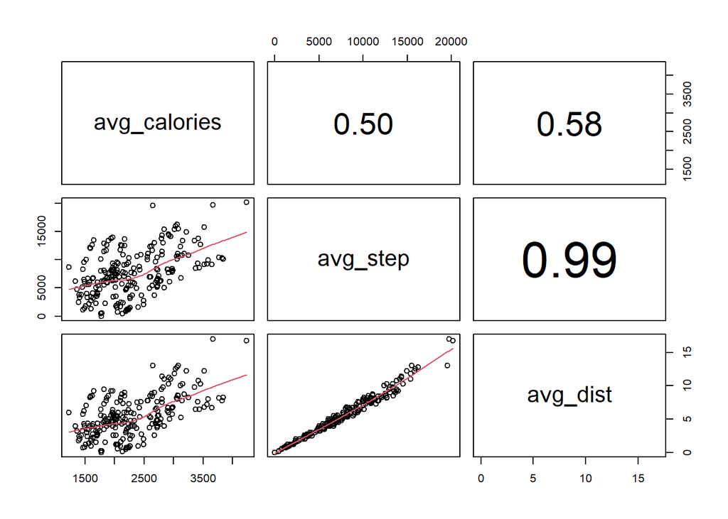

Figure 5.8: correlation between calories, distance and steps

```r
#correlation between calories, distance and steps
panel.cor <- function(x, y, digits = 2, prefix = "", cex.cor, ...) {
  usr <- par("usr")
  on.exit(par(usr))
  par(usr = c(0, 1, 0, 1))
  Cor <- abs(cor(x, y)) # Remove abs function if desired
  txt <- paste0(prefix, format(c(Cor, 0.123456789), digits = digits)[1])
  if(missing(cex.cor)) {
    cex.cor <- 0.4 / strwidth(txt)
  }
  text(0.5, 0.5, txt,
       cex = 1 + cex.cor * Cor) # Resize the text by level of correlation
}
pairs(~avg_calories+avg_step+avg_dist,data=active_analysis,upper.panel=panel.cor,lower.panel=panel.smooth)
```

# 6 Conclusion

The key insights in Chapter 5 can be summarized below:

1. Participants are more active in the morning and afternoon.
2. Majority of the participants fall under the unhealthy weight range.
3. Participants sleep more during the weekend.
4. Regular usage of smart device for sleep record lead to improve sleep quality.
5. Majority of participants are sedentary and lightly active.

Based on those insights, these are the recommendations with our stakeholders:

- **Target Audience**

- **Increased device engagement**

Since a significant proportion of participants are sedentary and lightly active, there is a need to implement gamification elements in the Bellabeat app to encourage more people to be active. An example is a Step Master Challenge, which is held monthly, whereby global participants compete for the highest number of steps. Participants are grouped based on their gender and have to accumulate at least 30 minutes of Moderate to Vigorous Physical Activities(MVPA) daily, which can be measured according to their heart rate. We recommend that the prizes can include Bellabeat products or vouchers. It not only helps to promote the company product, but it can also boost Bellabeat sales.

- **Commercials**

One surprising result from the sleep analysis is that increased device usage for sleep records may lead to better sleep quality. Further research is still needed to support this result. However, this can be one of the selling points in commercials to encourage those with sleep deprivation to purchase Bellabeat products. As the Leaf Tracker can be worn as a bracelet, necklace or clip, Bellabeat should also focus on this physical feature as the next selling point in their commercials. Moreover, as participants are more active in the morning and afternoon, Bellabeat ads can be broadcast before breakfast and noon.